# (Do you have bad genetics or...?)

## Investigation Overview

In this presentation I'll try to prove that the affect of physical characteristics of a crossfit athlete on their results is less significant than the effort that the athlete puts into their training.

## Dataset Overview

The dataset contains of information about 21k+ crossfite athletes that registered on a competition in 2015. The dataset contains athlete's physical and personal parameters and results in gymnastics and weightlifting

Athlete Parameteres:

- **gender** : Athlete's gender
- **age** : Athlete's age
- **height** : Athlete's height
- **weight** : Athlete's weight
- **background** : Athlete's sport background (if any)
- **schedule** : Athlete's workout schedule
- **howlong** : Athlete's crossfit experience

Athlete's Results:

- **weightlifting** : The sum of personal records in snatch, C&J, deadlift and backsquat
- **pullups** : Maximum unbroken pull-ups

```python
# import all packages and set plots to be embedded inline
import numpy as np
import pandas as pd
import matplotlib.pyplot as plt
import seaborn as sb

%matplotlib inline

# suppress warnings from final output
import warnings
warnings.simplefilter("ignore")
```

```python
# load in the dataset into a pandas dataframe
athletes = pd.read_csv('athletes_expl.csv')

# preliminary cleanup
# converting gender (unordered)
genders = ['Male', 'Female']
vclasses = pd.api.types.CategoricalDtype(ordered=False, categories=genders)
athletes['gender'] = athletes['gender'].astype(vclasses)

# converting gender (ordered from no background to pro)
backgrounds = ['No athletic background', 'Some sport (youth, school, recreational)', 'Pro or college sports']
vclasses = pd.api.types.CategoricalDtype(ordered=True, categories=backgrounds)
athletes['background'] = athletes['background'].astype(vclasses)

# converting schedules (ordered from one to multiple workouts per day)
schedules = ['One workout a day', 'One or multiple', 'Multiple workouts in a day']
vclasses = pd.api.types.CategoricalDtype(ordered=True, categories=schedules)
athletes['schedule'] = athletes['schedule'].astype(vclasses)

# converting howlong (ordered from less than year to 4+ years)
howlongs = ['Less than 1 year', '1-2 years', '2-4 years', '4+ years']
vclasses = pd.api.types.CategoricalDtype(ordered=True, categories=howlongs)
athletes['howlong'] = athletes['howlong'].astype(vclasses)
```

## Physical parameters vs results

Here are the plots that show the dependencies between athlete's weight and their results.

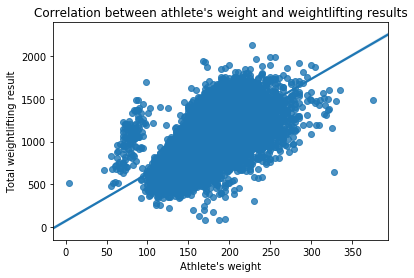

```python
sb.regplot(data=athletes, x='weight', y='weightlifting')
plt.xlabel("Athlete's weight")
plt.ylabel("Total weightlifting result")
plt.title("Correlation between athlete's weight and weightlifting results");
```

We can clearly see that there is a strong correlation. But in weightlifting competitions, there are weight categories, so all athletes have equal chances to succeed in their weight category.

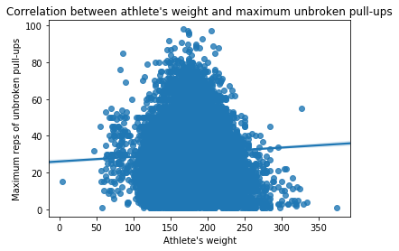

```python
sb.regplot(data=athletes, x='weight', y='pullups')
plt.xlabel("Athlete's weight")
plt.ylabel("Maximum reps of unbroken pull-ups")
plt.title("Correlation between athlete's weight and maximum unbroken pull-ups");
```

Here is a slight correlation, but in gymnastics there are no weight categories. But the next visual explains the situation:

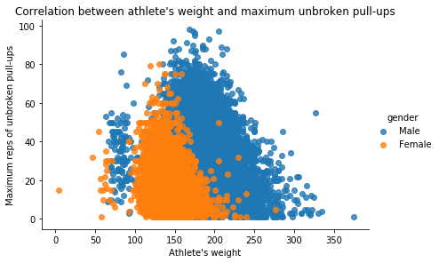

```python
g = sb.FacetGrid(data=athletes, hue='gender', height=4, aspect=1.5)
g = g.map(sb.regplot, 'weight', 'pullups', x_jitter=0.3, fit_reg=False)
g.add_legend()
plt.xlabel("Athlete's weight")
plt.ylabel("Maximum reps of unbroken pull-ups")
plt.title("Correlation between athlete's weight and maximum unbroken pull-ups");
```

And we can clearly see that it is pure gender effect. Males tend to weight more than females. They also tend to do more pullups. That's why there was a slight correlation between weight and pullups.

The next parameter is athlete's age

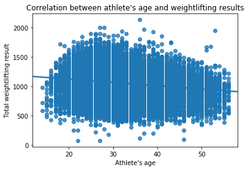

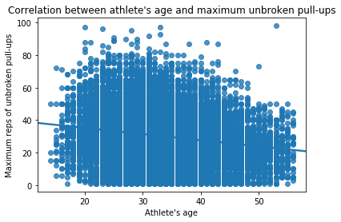

```python
plt.figure()
sb.regplot(data=athletes, x='age', y='weightlifting');
plt.xlabel("Athlete's age")
plt.ylabel("Total weightlifting result")
plt.title("Correlation between athlete's age and weightlifting results")

plt.figure()
sb.regplot(data=athletes, x='age', y='pullups')
plt.xlabel("Athlete's age")
plt.ylabel("Maximum reps of unbroken pull-ups")
plt.title("Correlation between athlete's age and maximum unbroken pull-ups");
```

Both kind of results tend to increase to ~18 years and then start to decrease after 35. That's exactly why individual competitions are for athletes from 18 to 35 years old.

We can conclude that weight and age have some affect on athlete's results, but since there are age and weight categories, all athletes have equal chances to succeed.

## Personal parameters vs results

Now I want to explore, how athlete's "personality" parameters affect their results.

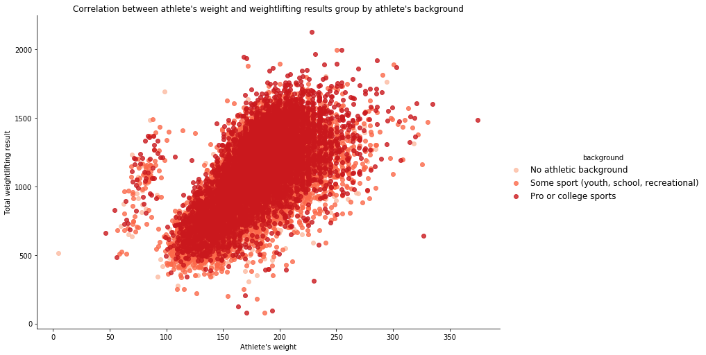

```python
g = sb.FacetGrid(data=athletes, hue='background', height=7, aspect=1.5, palette='Reds')
g = g.map(sb.regplot, 'weight', 'weightlifting', x_jitter=0.9, fit_reg=False)
g.add_legend(fontsize='12')
plt.xlabel("Athlete's weight")
plt.ylabel("Total weightlifting result")
plt.title("Correlation between athlete's weight and weightlifting results group by athlete's background");
```

But there are enough light-red points on the middle and top sides of the plot. It shows that people with non-pro athletic background can achieve the same results as ex-pros in crossfit.

Now I want to plot the same scatter but use athlete's experience level as hue.

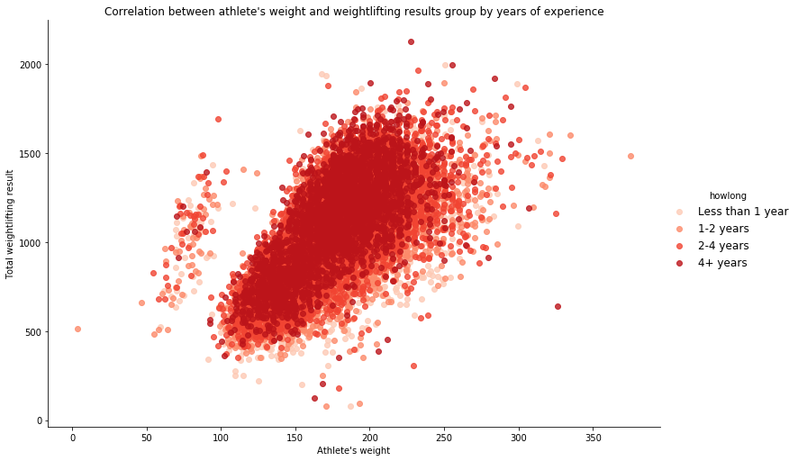

```python
g = sb.FacetGrid(data=athletes, hue='howlong', height=7, aspect=1.5, palette='Reds')
g = g.map(sb.regplot, 'weight', 'weightlifting', x_jitter=0.9, fit_reg=False)
g.add_legend(fontsize='12')
plt.xlabel("Athlete's weight")
plt.ylabel("Total weightlifting result")
plt.title("Correlation between athlete's weight and weightlifting results group by years of experience");
```

The correlation is much stronger in this case. We can clearly see that experienced athletes tend to lift more weights with lower bodyweight.

Now same plot but schedule highlighted.

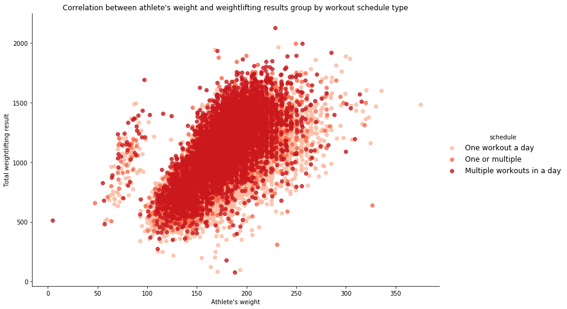

```python
g = sb.FacetGrid(data=athletes, hue='schedule', height=7, aspect=1.5, palette='Reds')
g = g.map(sb.regplot, 'weight', 'weightlifting', x_jitter=0.9, fit_reg=False)
g.add_legend(fontsize='12')
plt.xlabel("Athlete's weight")
plt.ylabel("Total weightlifting result")
plt.title("Correlation between athlete's weight and weightlifting results group by workout schedule type");
```

This plot shows another type of correlation. Athletes who don't include days with multiple workouts tend to lose to those who does multiple workouts per day.

Now I want to plot a correlation between weightlifting results, schedule and experience. The best choice of plot type is clustered bar chart.

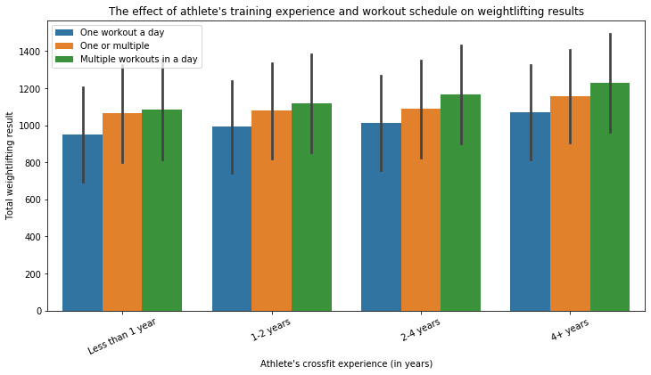

```python
plt.figure(figsize=(12,6))
sb.barplot(data=athletes, x='howlong', y='weightlifting', hue='schedule', ci='sd')
plt.legend(loc=2)
plt.xticks(rotation=25)
plt.xlabel("Athlete's crossfit experience (in years)")
plt.ylabel("Total weightlifting result")
plt.title("The effect of athlete's training experience and workout schedule on weightlifting results");
```

We can clearly see that it is all about efforst. Years of experience + frequent training!

The similar plot for pullups:

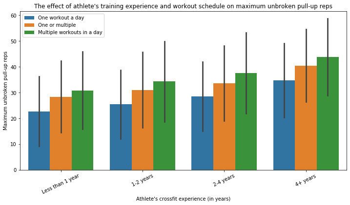

```python
plt.figure(figsize=(12,6))
sb.barplot(data=athletes, x='howlong', y='pullups', hue='schedule', ci='sd')
plt.legend(loc=2)
plt.xticks(rotation=25)
plt.xlabel("Athlete's crossfit experience (in years)")
plt.ylabel("Maximum unbroken pull-up reps")
plt.title("The effect of athlete's training experience and workout schedule on maximum unbroken pull-up reps");
```

And here is clearly the same situation.

At this point, I can conclude the following:

**The data shows that physical characteristics and professional background do not have much effect on results. The more efforts an athlete puts into training, the better results he will get.**